# Árboles de regresión

Javier Cara

curso 2018-19

# 1 Estimación de los árboles de regresión

```r
library(tree)
datos = read.table('coches.txt',header=T)
```

```r
t1 = tree(consumo ~ .,data=datos)
```

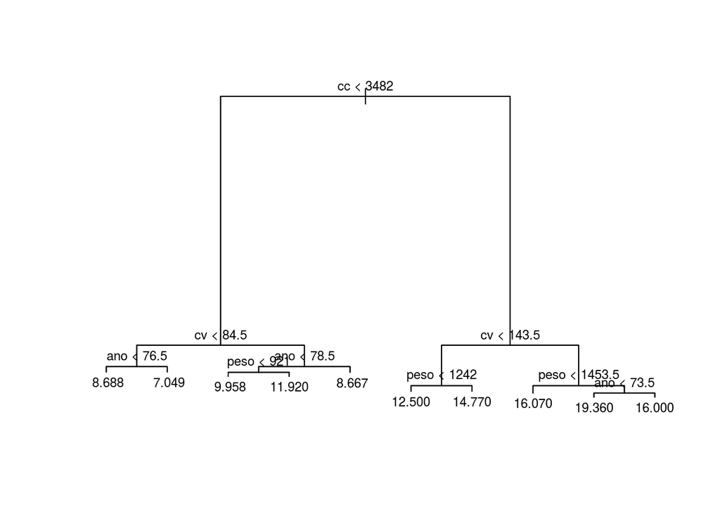

```r
plot(t1)
text(t1, cex = 0.75)
```

```r
summary(t1)
```

```
##
## Regression tree:
## tree(formula = consumo ~ ., data = datos)
## Variables actually used in tree construction:
## [1] "cc"   "cv"   "ano"  "peso"
## Number of terminal nodes:  10
## Residual mean deviance:  2.142 = 816 / 381
## Distribution of residuals:
##     Min.  1st Qu.   Median     Mean  3rd Qu.     Max.
## -6.50000 -0.95830 -0.04938  0.00000  0.93480  5.50000
```

Los regresores que son influyentes en el consumo son los que se han empleado en las particiones.

```r
print(t1)
```

```
## node), split, n, deviance, yval
##       * denotes terminal node
##
##  1) root 391 5911.00 11.230
##    2) cc < 3482 234  856.20  8.709
##      4) cv < 84.5 129  217.00  7.659
##        8) ano < 76.5 48   54.31  8.688 *
##        9) ano > 76.5 81   81.80  7.049 *
##      5) cv > 84.5 105  322.00 10.000
##       10) ano < 78.5 72  169.10 10.610
##         20) peso < 921 48   69.92  9.958 *
##         21) peso > 921 24   37.83 11.920 *
##       11) ano > 78.5 33   67.33  8.667 *
##    3) cc > 3482 157 1359.00 14.980
##      6) cv < 143.5 82  358.00 13.110
##       12) peso < 1242 60  185.00 12.500 *
##       13) peso > 1242 22   89.86 14.770 *
##      7) cv > 143.5 75  399.90 17.030
##       14) peso < 1453.5 46  132.80 16.070 *
##       15) peso > 1453.5 29  157.20 18.550
##         30) ano < 73.5 22   85.09 19.360 *
##         31) ano > 73.5 7   12.00 16.000 *
```

Lo que devuelve la tabla es:

- Numero del nodo
- split: criterio para hacer la partición del nodo
- n: numero de datos que componen el nodo.
- deviance: = RSS = $\sum(y_i - \hat{y}_i)^2$.

```r
n = nrow(datos)
( deviance_root = sum( (datos$consumo - mean(datos$consumo))^2 ) )
```

```
## [1] 5910.742
```

- yval: predicción del nodo = $\bar{y}$

```r
mean(datos$consumo)
```

```
## [1] 11.22762
```

- un asterisco * para indicar un nodo terminal u hoja.

# 2 Parámetros del árbol

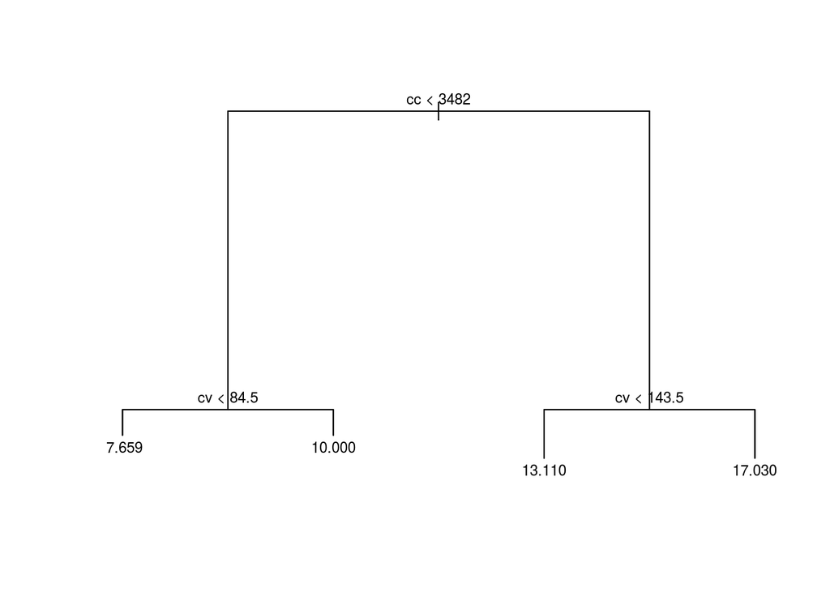

```r
t2 = tree(consumo ~ .,data=datos, control = tree.control(nobs=nrow(datos),mincut = 20,minsize = 40,mindev = 0.05))
plot(t2)
text(t2, cex=.75)
```

control:

- minsize: tamaño mínimo del nodo para que se divida en dos (por defecto, minsize = 10).
- mincut: si al dividir un nodo, uno de los nodos hijo tiene un tamaño inferior a éste, no se divide el nodo (por defecto, mincut = 5). Ojo, mincut ha de ser menor que minsize/2.
- mindev: para que un nodo se divida, la deviance del nodo tiene que ser mayor que mindev por la deviance del nodo raiz.

```r
print(t2)
```

```
## node), split, n, deviance, yval
##       * denotes terminal node
##
## 1) root 391 5911.0 11.230
##   2) cc < 3482 234  856.2  8.709
##     4) cv < 84.5 129  217.0  7.659 *
##     5) cv > 84.5 105  322.0 10.000 *
##   3) cc > 3482 157 1359.0 14.980
##     6) cv < 143.5 82  358.0 13.110 *
##     7) cv > 143.5 75  399.9 17.030 *
```

- si queremos obtener un árbol que se ajusta perféctamente a los datos hay que utilizar mindev = 0 y minsize = 2. Estos árboles predicen muy mal porque son muy sensibles a ligeros cambios en los datos.

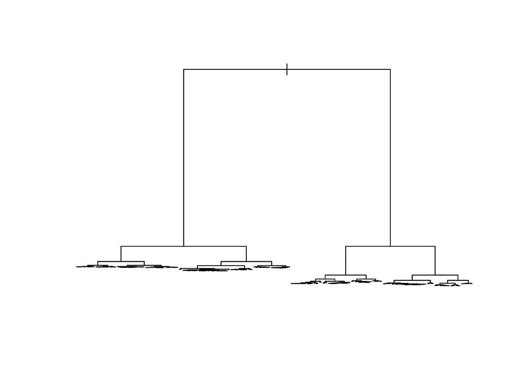

```r
t3 = tree(consumo ~ ., data=datos, control = tree.control(nobs=nrow(datos),minsize = 2,mindev = 0.0))
plot(t3)
```

```r
#text(t3, cex=.75)
```

# 3 Podado

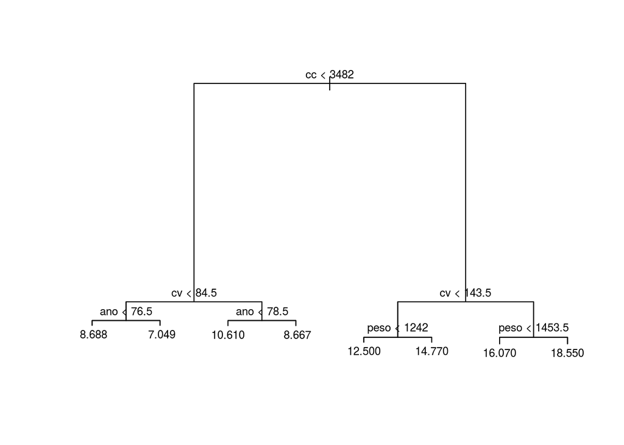

```r
t3_prune = prune.tree(t3, best = 8)
plot(t3_prune)
text(t3_prune, cex=.75)
```

# 4 Training set *vs* Test set

Dividimos los datos en dos partes, una para entrenar el modelo y otra para calcular el error de predicción con datos diferentes de los utilizados para entrenar:

```r
set.seed(321)
ndat = nrow(datos)
train = sample(1:ndat,ndat/2) # la mitad de los datos para entranamiento
datos_train = datos[train,] # trainning set
datos_test = datos[-train,] # test set
```

Entrenamiento del modelo

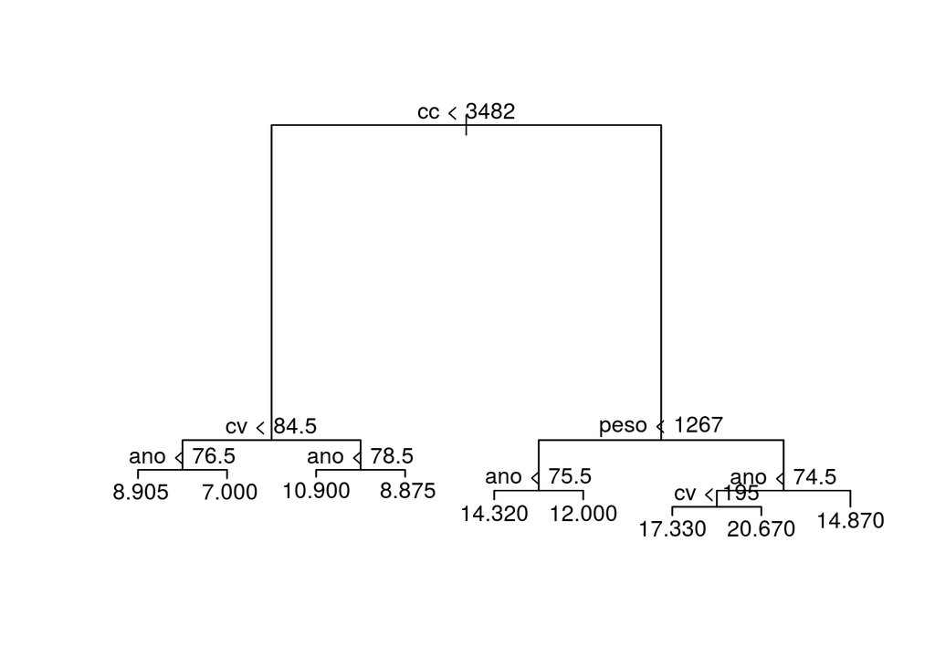

```r
t3 <- tree(consumo ~ ., data = datos_train)
plot(t3)
text(t3)
```

## 4.1 Error del modelo

```r
y_train_p <- predict(t3, newdata = datos_train)
```

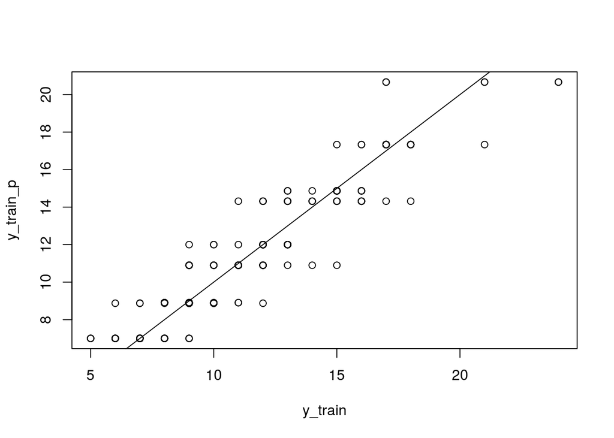

```r
y_train = datos_train$consumo
plot(y_train,y_train_p)
abline(0,1) # como pintamos y vs yp, la relacion perfecta deberia ser una recta a 45º (m=1)
```

```r
( MSE_train = mean((y_train-y_train_p)^2) ) # error cuadratico medio en los datos de training
```

```
## [1] 1.703067
```

## 4.2 Error de predicción

```r
# prediccion del consumo con los datos de test
y_test_p = predict(t3, newdata = datos_test)

# error del test set
y_test = datos_test$consumo
(MSE_test = mean((y_test-y_test_p)^2))
```

```
## [1] 3.114328
```

El error es mucho mayor con los datos de validación!